##### Models for Socio-Environmental Data

##### A Spatial Model for Continuous Data

##### June 13, 2019

### **Motivation**

Most socio-ecological data are spatial. Observations that are close to each other in space are often more similar to one another than observations that are far away. This similarity is not necessarily a problem, but it can cause a problem in our inference. Recall that a fundamental assumption of a statistical inference is that the differences between model predictions and data are independent and identically distributed, which for real-valued observations means:

$$\begin{align}
\mu_i&=g(\boldsymbol{\theta},\mathbf{x_i})\\
e_i&=y_i-\mu_i\\
e_{i}&\overset{\text{iid}}{\sim}\text{normal}(0,\sigma^{2}).
\end{align}$$

Note that we are not assuming that the data are independent, rarely will that be true, but rather that the model residuals, are iid after the effects of covariates are included in model predictions. Failing to meet this assumption means that our inference will be excessively optimistic, which means that marginal posterior distributions of quantities of interest will be narrower than they should be. We say that residuals are autocorrelated when residuals that are close together in space (or time) are smaller than those that are far apart. The problem of spatial autocorrelation is frequently brushed aside without thoughtful treatment. Here, we will learn how to determine if autocorrelation is a problem, and if it is, how to model the spatial structure in the residuals so that our inferences account for it.

### **R libraries needed for this lab**

You need to load the following libraries. Set the seed to 10 to compare your answers to ours.

```r
library(rjags)
library(MCMCvis)
library(MASS)
library(ggplot2)
library(viridis)
library(gridExtra)
library(gstat)
library(sf)
library(parallel)
library(stringr)
set.seed(10)
```

### **Simulating spatial data**

Consider the following code for simulating spatially structured data where the data are points with spatial coordinates that could be specified, for example, by UTM meters. Study the code relative to the lecture notes on models for point data. This lab will not consider areal data when spatial structure is specified as a network. The goal here is to create structured y values:

$$\begin{align*}
\mathbf{y} & \sim \text{multivariate normal} (g(\boldsymbol{\theta},\mathbf{X})+\boldsymbol{\eta},\sigma_{\varepsilon}^{2}\mathbf{I})\\
\boldsymbol{\eta} & \sim \text{normal}(0,\boldsymbol{\Sigma)}
\end{align*}$$

These steps are taken directly from the final slide of the Continuous Spatial Models lecture.

1. Choose locations $s_{i}$ for $i=1,...,n$. Decide the number of data points `np` and set the maximum extent of the spatial area which we define with `limit`. Here we set `limit` to 1000 (the units don’t matter, we will think of it as meters for example). Now make some random coordinates inside the spatial area defined by `limit` for our observations and save these values in the data frame `M_df`. Let’s convert this data frame to a simple features data frame from the [`sf` package](https://www.r-spatial.org/r/2016/02/15/simple-features-for-r.html) using the `sf::st_as_sf` function. Simple features are an **incredibly useful** way to manipulate spatial data in R. Simple feature data frames work just like normal data frames, except that it has one special column designated as the objects geometry. This geometry is a simple feature that can be a polygon, line, multi-line, point, etc., and each row of an `sf` data frame is associated with one simple feature (in our case a point). Part of a simple feature object is the coordinate reference system or CRS of the geometry, which is specified with the `crs` argument. Here in this simulated example we just assign it WGS84 UTM Zone 10 (`crs=32610`) but really it could be any planar coordinate reference system. For easy tutorial of simple features and coordinate reference systems, we highly recommend Jessica Sadler’s blog posts [here](https://www.jessesadler.com/post/gis-with-r-intro/) and [here](https://www.jessesadler.com/post/simple-feature-objects/).

```r
np = 100
limit = 1000
easting = runif(np, 0, limit - 1)
northing = runif(np, 0, limit - 1)
M_df = data.frame(easting, northing)
M_sf <- sf::st_as_sf(M_df, coords = c("easting", "northing"), crs = 32610)
```

2. Define the mean $\mu$ of the multivariate normal distribution as the function $g(\boldsymbol{\theta},\mathbf{X})$. To do this you will set some parameter values $\boldsymbol{\theta}$ that we will use to construct a response based on two covariates: `x1` and `x2`. We will make these spatially structured covariates. The details of this are not important but what is important to know is that these covariates are more alike the closer they are to one another. Then we will calculate $\mu$ for each point.

```r
beta1 = 2.3
beta2 = 8
beta3 = -6
M_sf$x1 = -cos(as.vector(scale(st_coordinates(M_sf)[, 1] - .5)) * cos(as.vector(scale(st_coordinates(M_sf)[, 2]))))
M_sf$x2 = as.vector(scale(st_coordinates(M_sf)[, 1])) + as.vector(scale(st_coordinates(M_sf)[, 2]))
M_sf$mu = beta1 + beta2 * M_sf$x1 + beta3 * M_sf$x2
```

3. Let’s plot each covariate to get a sense of how their values are distributed spatially.

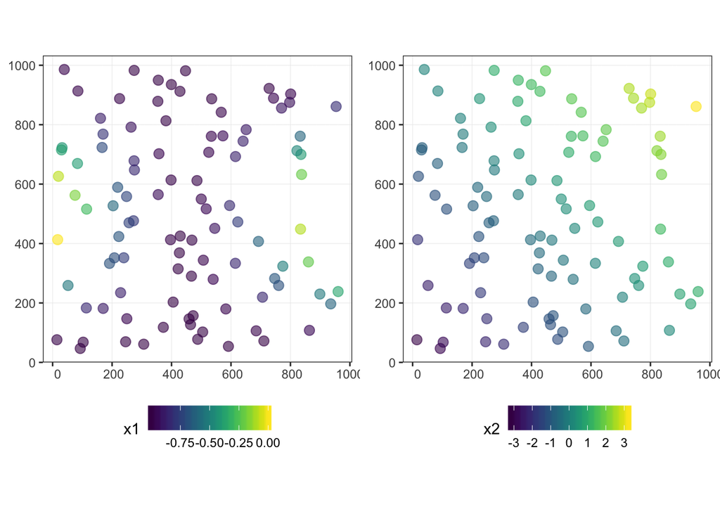

```r
g1 <- ggplot() +
  geom_sf(data = M_sf, aes(color = x1), size = 3, alpha = .6) +
  theme_bw() +
  scale_color_viridis() +
  coord_sf(datum = st_crs(32610)) +
  theme(legend.position = "bottom")

g2 <- ggplot() +
  geom_sf(data = M_sf, aes(color = x2), size = 3, alpha = .6) +
  theme_bw() +
  scale_color_viridis() +
  coord_sf(datum = st_crs(32610)) +
  theme(legend.position = "bottom")

gridExtra::grid.arrange(g1, g2, nrow = 1)
```

4. Choose the unstructured variance $\sigma^{2}_{\epsilon}$, structured variance component $\sigma^{2}$, and range parameter $\phi$.

```r
sigma.eps = 1
sigma.s = 5
phi = 100
```

5. Compute the distance matrix `D` between all `np` locations of interest using the `st_distance` function. The output is a matrix of pairwise distances between all the points.

```r
D = st_distance(M_sf)
```

6. Calculate covariance matrix for the spatially correlated errors (you can ignore the warning):

$$\Sigma_{i,j}=\sigma^{2}\exp\left(-\frac{d_{i,j}}{\phi}\right)$$

```r
Sigma = sigma.s * exp(-D / phi)
```

```
## Warning in Math.units(-D/phi): Operation exp not meaningful for units
```

$$\mathbf{y} \sim \text{multivariate normal} (g(\boldsymbol{\theta},\mathbf{X}),\sigma_{\varepsilon}^{2})$$

```r
M_sf$y = rnorm(np, beta1 + beta2 * M_sf$x1 + beta3 * M_sf$x2, sigma.eps)
```

8. Create a spatially structured response variable `y` by using $\Sigma$ to add a 0 centered spatially structured random variable to the unstructured `y`. To do this, we make a vector of draws from a multivariate distribution with first parameter a vector of zeros of length `np` and second parameter `Sigma` computed above.

$$\begin{align*}
\mathbf{y} & \sim \text{multivariate normal} (g(\boldsymbol{\theta},\mathbf{X})+\boldsymbol{\eta},\sigma_{\varepsilon}^{2}\mathbf{I})\\
\boldsymbol{\eta} & \sim \text{normal}(0,\boldsymbol{\Sigma)}
\end{align*}$$

```r
eta = as.vector(mvrnorm(1, rep(0, np), Sigma))
M_sf$y.structured <- M_sf$y + eta
```

9. Let’s plot the structured and unstructured response variable.

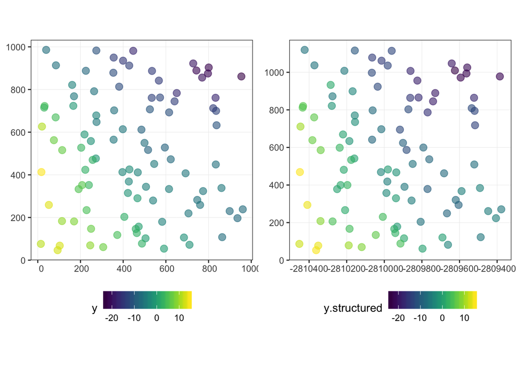

```r
g3 <- ggplot() +
  geom_sf(data = M_sf, aes(color = y), size = 3, alpha = .6) +
  theme_bw() +
  scale_color_viridis() +
  coord_sf(datum = st_crs(32610)) +
  theme(legend.position = "bottom")

g4 <- ggplot() +
  geom_sf(data = M_sf, aes(color = y.structured), size = 3, alpha = .6) +
  theme_bw() +
  scale_color_viridis() +
  coord_sf(datum = st_crs(26914)) +
  theme(legend.position = "bottom")

gridExtra::grid.arrange(g3, g4, nrow = 1)
```

10. Plot the semivariance. Remember from lecture that that the semivariance is:

$$\gamma(d) = \text{cov}(0) - \text{cov}(d) + \sigma^{2}_{\epsilon}$$

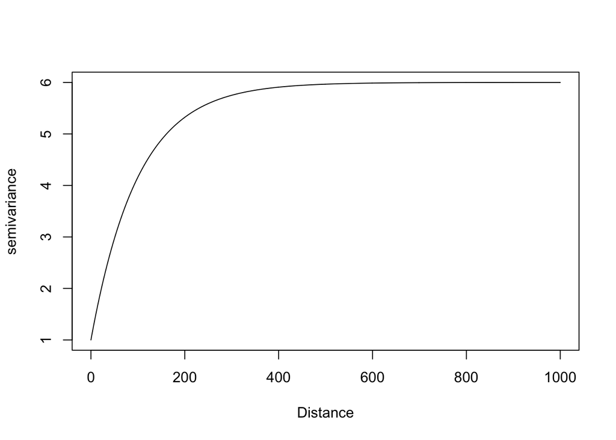

```r
distance_plot = seq(0, limit, 1)
y.sig = sigma.s - sigma.s * (exp(-distance_plot / phi)) + sigma.eps
plot(distance_plot, y.sig, xlim = c(0, 1000), type = "l", ylab = "semivariance", xlab = "Distance")
```

### **An aspatial model for spatially structured data**

Consider an aspatial model that you will fit to the spatially structured data using the following code:

$$\begin{align*}
[\boldsymbol{\beta},\sigma\mid\mathbf{y}]&\propto \prod_{i=1}^n\text{normal}(y_i\mid \mathbf{x}_i'\boldsymbol{\beta}, \sigma^2)\\
&\times \prod_{j=1}^3\text{normal}(\beta_j\mid 0, 10000)\text{uniform}(\sigma\mid 0, 50),
\end{align*}$$

First, create model matrix with column of 1’s for intercept.

```r
X = cbind(rep(1, nrow(M_sf)), M_sf$x1, M_sf$x2)
data = list(y = M_sf$y.structured, X = X)
```

Here is the JAGS code.

```r
{sink("AspatialJAGS.R")
cat("
model {

  #priors
  for(i in 1:3) {
    beta[i] ~ dnorm(0, .00001)
  }
  sigma.eps ~ dunif(0, 50)
  tau <- 1 / sigma.eps^2

  #likelihood
  mu = X %*% beta
  for (i in 1:length(y)) {
    y[i] ~ dnorm(mu[i], tau)
    y.new[i] ~ dnorm(mu[i], tau)
    e[i] <- y[i] - mu[i]
  }

  # derived quantities
  p.mean <- step(mean(y.new) - mean(y))
  p.sd <- step(sd(y.new) - sd(y))

}

",fill = TRUE)
sink()}
```

The model converges, but we might want more iterations to increase the effective sample size above 5000 for all quantities of interest. The model passes posterior predictive checks nicely (how can you tell?)

```r
jm = jags.model("AspatialJAGS.R", data = data, n.chains = 3)
update(jm, n.iter = 15000)
zc = coda.samples(jm, n.iter = 10000, variable.names = c("beta", "sigma.eps", "p.mean", "p.sd", "e"))
MCMCsummary(zc, excl = "e", n.eff = TRUE)
```

```
##                 mean        sd      2.5%       50%     97.5% Rhat n.eff
## beta[1]    2.5703935 0.8088666  1.005389  2.570658  4.166982    1  1361
## beta[2]    9.1545151 0.9483296  7.314544  9.159025 11.007780    1  1348
## beta[3]   -6.1612275 0.1671968 -6.490143 -6.161451 -5.835926    1 30000
## p.mean     0.5023667 0.5000027  0.000000  1.000000  1.000000    1 30339
## p.sd       0.5174000 0.4997055  0.000000  1.000000  1.000000    1 22771
## sigma.eps  2.3339432 0.1694307  2.028375  2.323977  2.693879    1 16241
```

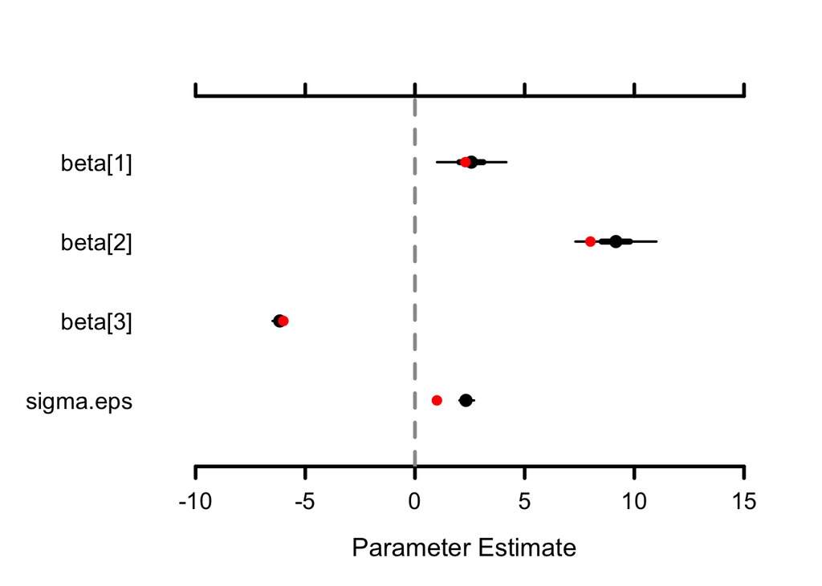

```r
MCMCplot(zc, params = c("beta", "sigma.eps"))
points(beta1, 4, col = "red", pch = 16, cex = 1.2)
points(beta2, 3, col = "red", pch = 16, cex = 1.2)
points(beta3, 2, col = "red", pch = 16, cex = 1.2)
points(sigma.eps, 1, col = "red", pch = 16, cex = 1.2)
```

We need to examine the possibility for spatial autocorrelation in the residuals by plotting a semivariogram, a plot of the semivariance as a function of distance between points. We will use the `variogram` function from the `gstats` package to do this. Remember that the y-axis is gamma:

$$\tilde{\gamma}(d)=\frac{\sum_{i,j\in N(d)}(e_{i}-e_{j})^{2}}{2N(d)}$$

where $N(d)$ is the number of pairs of residuals at distance `d`. Consider the following code and output:

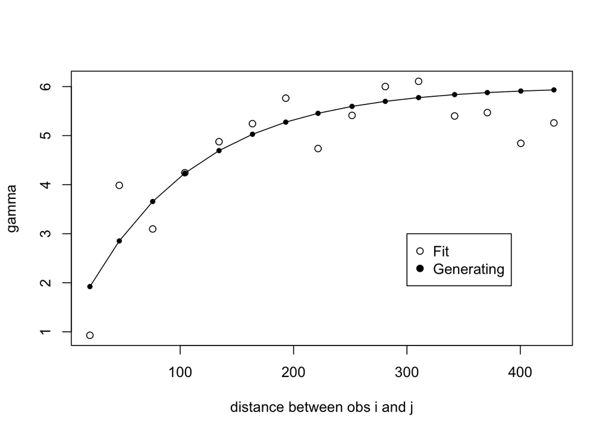

```r
M_sf$epsilon <- MCMCpstr(zc, params = "e", func = median)$e
eps_v <- gstat::variogram(epsilon ~ 1, M_sf)
plot(eps_v$dist, eps_v$gamma, xlab = "distance between obs i and j", ylab = "gamma")
semivar.gen = (sigma.s - sigma.s * exp(-eps_v$dist * 1 / phi)) + sigma.eps
lines(eps_v$dist, semivar.gen, type = "o", pch = 20)
legend(300, 3, c("Fit", "Generating"), pch = c(1, 19), bty = "y", cex = 1)
```

#### **A spatial model for spatially structured data**

Write an expression for the posterior and factored joint distribution for a model that accounts for spatial structure in the data. It will be important to use the hierarchical approach illustrated in lecture where you add a zero centered, spatially structured random variable to the predictions of the process model:

$$\begin{align}
\mathbf{y}&\sim\text{multivariate normal}(\mathbf{X}\boldsymbol{\beta}+\boldsymbol{\eta},\sigma_{\epsilon}^{2}\mathbf{I})\\
\boldsymbol{\eta}&\sim\text{multivariate normal}(\boldsymbol{\eta}\mid \mathbf{0},\boldsymbol{\Sigma})\\
\boldsymbol{\Sigma} &= \sigma^2 e^{(\frac{-\mathbf{D}}{\phi})}
\end{align}$$

Write JAGS code to approximate the marginal posterior distributions of the unobserved quantities from the spatial model you just specified. Spatial models tend to run slowly the large covariance matrix is large. Moreover, fitting these models requires many data points, so we can’t speed the process by making a small, simulated data set. We have provided the R code to allow you to run your model in parallel. All you need to do is write the JAGS code for the model. You may omit posterior predictive checks to reduce execution time. Here are some hints that will be important for coding. **To learn about coding JAGS models to run in parallel revisit Section 8 of the JAGS Primer.**

1. Remember that the multivariate normal distribution in JAGS requires a precision matrix as the second argument, which is the inverse of the covariance matrix.
2. You can create a zero centered random variable reflecting spatial structure using code below where `mu.eta` is a vector of zeros whose length equals number of rows in `Cov.mat`.

```r
for(i in 1:length(y)){
  mu_eta[i] <- 0
  for(j in 1:length(y)){
    Cov.mat[i, j] <- sigma.s^2 * exp(-D[i, j] / phi)
  }
}
eta ~ dmnorm(mu_eta, inverse(Cov.mat))
```

3. It is vital that you compute the residuals using `e <- y - mu - eta` where `y` is a vector containing the response data; `mu` is a vector of model predictions, and `eta` is the zero centered random variable needed in the hierarchical approach. Subtracting the spatially structured random variable `eta` should produce a variogram without spatial dependence.
4. You will need an identity matrix of proper dimension, that is a matrix with ones on the diagonal and zeros elsewhere. Make this on the R sides and include it in your data list as shown below.
5. We are running the model a lot longer than you might have time for. In that case set the burn-in and samples kept to ~5000.

```r
n.adapt = 500
n.update = 25000
n.iter = 10000

X1 = rep(1, nrow(M_sf))
X = cbind(X1, M_sf$x1, M_sf$x2)
y.I = matrix(nrow = nrow(M_sf), ncol = ncol(X))
y.I = diag(1, nrow(X))
data = list(D = D, X = X, y.np = ncol(X), y = M_sf$y.structured, y.I = y.I)
```

```r
cl <- makeCluster(3)

myWorkers <- NA
for(i in 1:3) myWorkers[i] <- word(capture.output(cl[[i]]), -1)

initsP = list(
  list(beta = c(2.3, 8, -6), sigma.s = 1, sigma.u = 5, phi = 100,
    RNG.seed = 1, .RNG.name = "base::Mersenne-Twister"),
  list(beta = c(2.2, 7.8, -5.8), sigma.s = 1.1, sigma.u = 4.8, phi = 90,
    RNG.seed = 11, .RNG.name = "base::Mersenne-Twister"),
  list(beta = c(2.4, 8.1, -6.3), sigma.s = .9, sigma.u = 5.3, phi = 110,
    RNG.seed = 183, .RNG.name = "base::Mersenne-Twister"))

parallel::clusterExport(cl, c("myWorkers", "data", "initsP", "n.adapt", "n.update", "n.iter"))

out <- clusterEvalQ(cl, {
  library(rjags)
  jm = jags.model("SpatialJAGS.R", data = data, n.chains = 1,
  n.adapt = n.adapt, inits = initsP[[which(myWorkers==Sys.getpid())]])
  update(jm, n.iter = n.update)
  zm = coda.samples(jm, variable.names = c("beta", "e", "sigma.eps", "sigma", "phi"),
  n.iter = n.iter, thin = 5)
  return(as.mcmc(zm))
})

stopCluster(cl)
zmP = mcmc.list(out)
```

Produce new output from your spatially structured model. Compare it with the output from the aspatial model. What is different about the marginal posteriors? Examine evidence for autocorrelation with a semivariogram. What do you conclude?